# two-proportion z-test

theory based approach

Dr. Reynolds

In this section, we want to know: for two different groups, is there a difference in the proportion for another variable.

Let’s consider a case: **An experiment is run where people are basically asked “how are things going in your life this year?”, but wording is slightly different: 1) “Are you having a good year?” 2) “Are you having a bad year?”. Their responses are classified as “positive” or “negative”.**

Let’s answer the question: **Is there evidence that there is an association (relationship) between the way the question is asked and how people respond**

```r
read_csv(file = "https://raw.githubusercontent.com/EvaMaeRey/teaching_spring_2021/master/data/chap5.GoodandBad.csv") %>%
  rename(wording = Wording) %>% # getting to "snake case" all lower w/ underscores
  rename(perception = Perception) ->
good_bad

good_bad
```

```
## # A tibble: 30 x 2
##    wording  perception
##    <chr>    <chr>
##  1 goodyear positive
##  2 goodyear negative
##  3 badyear  positive
##  4 goodyear positive
##  5 goodyear negative
##  6 badyear  positive
##  7 goodyear positive
##  8 goodyear positive
##  9 goodyear positive
## 10 badyear  negative
## # … with 20 more rows
```

# Part 1. Representing bivariate (two variable), binary (two categories) associations

There are a **large** number of ways to represent associations between two binary variables.

- contingency table (or 2X2 table)
- stacked bar chart
- dodged bar chart
- mosaic plot/variable widths bar plot
- segmented bar chart (book uses a lot)

## First representation

What’s the name of this first representation?

> your answer (choose 1) contingency table (or 2X2 table), stacked bar chart, dodged bar chart, mosaic plot/variable widths bar plot, segmented bar chart (book uses a lot)

```r
good_bad %>%
  table()
```

```
##           perception
## wording    negative positive
##   badyear         8        4
##   goodyear        3       15
```

## Second representation

We can pipe the above table to plot() and get a visualization. What’s it called:

> your answer (choose 1) contingency table (or 2X2 table), stacked bar chart, dodged bar chart, mosaic plot/variable widths bar plot, segmented bar chart (book uses a lot)

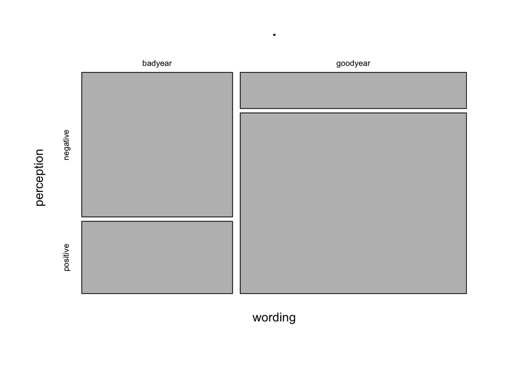

```r
good_bad %>%
  table() %>%
  plot()
```

## Third and fourth representations

A more common representations (in newspapers) are below…

Which do you think those are called?

> your answer (choose 2) contingency table (or 2X2 table), stacked bar chart, dodged bar chart, mosaic plot/variable widths bar plot, segmented bar chart (book uses a lot)

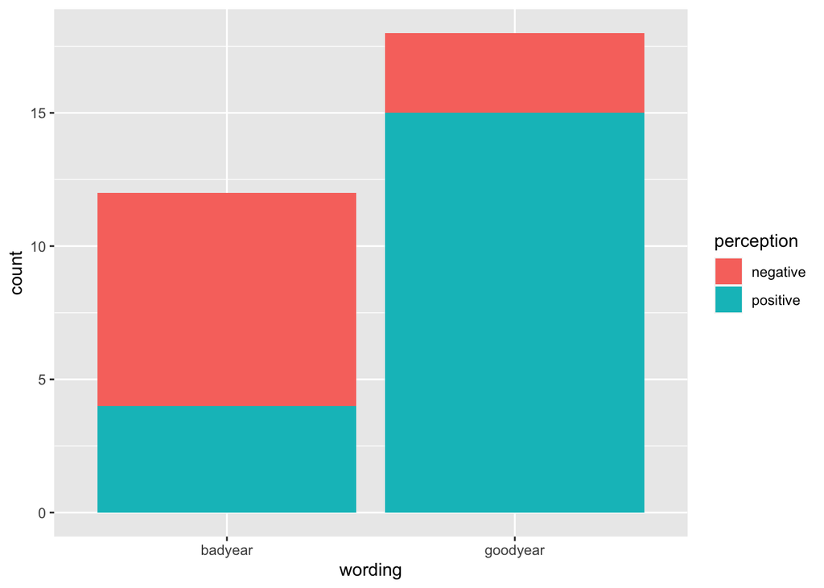

```r
ggplot(data = good_bad) +
  aes(x = wording) +
  geom_bar() +
  aes(fill = perception)
```

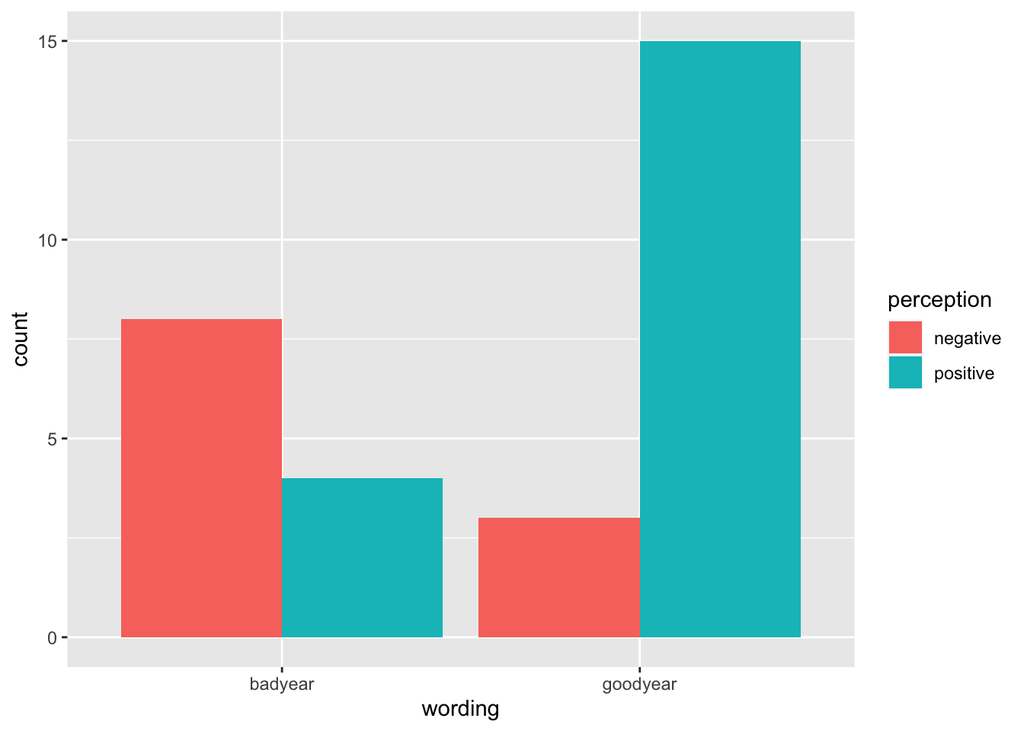

```r
ggplot(data = good_bad) +
  aes(x = wording) +
  geom_bar(position = "dodge") +
  aes(fill = perception)
```

## Fifth representation used a lot in the book

We see a lot of this one in the book. What’s its name?

> your answer (choose 1) contingency table (or 2X2 table), stacked bar chart, dodged bar chart, mosaic plot/variable widths bar plot, segmented bar chart (book uses a lot)

Using the visualization, eyeball the difference in proportions.

> your answer …

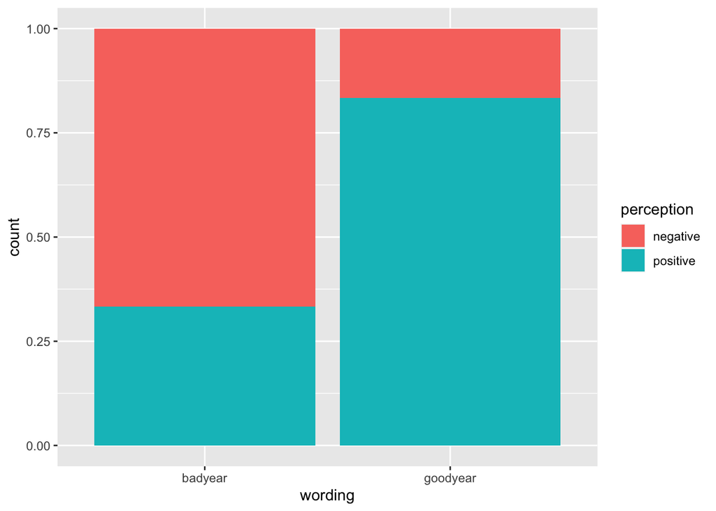

```r
ggplot(data = good_bad) +
  aes(x = wording) +
  geom_bar(position = "fill") +
  aes(fill = perception)
```

## Pooled proportion

Below, we *ignore the grouping information*, looking at the overall proportion (pooled proportion) across both groups.

Estimate the pooled proportion based on the data visualization:

> your answer

This proportion is used in the calculation of the SE for the null distribution.

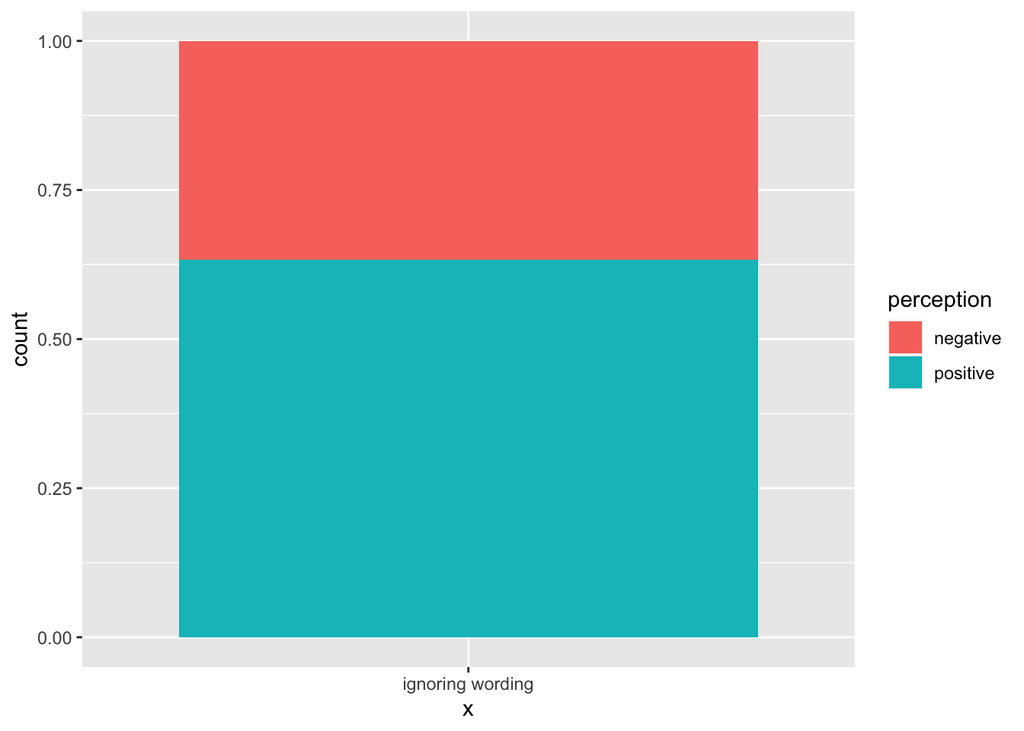

```r
ggplot(data = good_bad) +
  aes(x = "ignoring wording") +
  geom_bar(position = "fill") +
  aes(fill = perception)
```

# Part 2. Theory based approach - How to conduct a **two-proportion z-test**

## Step 1: Statistic: difference in proportions

Our statistic is the difference in proportions for between the two groups.

$$\hat{p}_1 - \hat{p}_2$$

Hide the definition above from yourself, and look only at the formula, try to describe the statistic in words:

> your answer

Look at the contingency table…

```r
good_bad %>%
  table()
```

```
##           perception
## wording    negative positive
##   badyear         8        4
##   goodyear        3       15
```

… and use r as a calculator to calculate the value of the statistic, phat-1 (good year condition) minus phat-2 (bad year condition).

## Step 2: Characterize the distribution for the null

What are differences in proportions for the two groups that might have arisen *just by chance*?

Standardized statistic - z score, it is hypothesized that there is usually that no difference in the proportions (pi) for these groups.

$$H_0: \pi_{good~framing}- \pi_{bad~framing} = 0$$

$$H_A: \pi_{good~framing}- \pi_{bad~framing} \ne 0$$

Another way we describe $H_0$ this is that the variables are **statistically independent**, i.e. *knowing the value of one var doesn’t tell you information about the other variable*.

This is in contrast to **statistical dependence** – *there is a real association between the variables*, or $H_A$ (specifically the not equal case).

If we have enough evidence for **statistical dependence** (i.e. p-value < alpha) – we can say the relationship is **statistically significant**! Yea!

$$SE = \sqrt{\hat{p}(1-\hat{p})*(\frac{1}{n_1}+\frac{1}{n_2})}$$

Looking at the equation above use R as a calculator to calculate the standard error (SE) - the expected spread (variability) consistent with no relationship (chance model); the spread is centered at zero (no difference in proportions).

$$z = \frac{observed~statistic-hypothesized~value}{standard~error~of~statistic}$$

Or

$$z = \frac{(\hat{p}_1 - \hat{p}_2)-0}{\sqrt{\hat{p}(1-\hat{p})*(\frac{1}{n_1}+\frac{1}{n_2})}}$$

## Step 3a: Strength of evidence - zscore

Is what I observe (phat1 - phat2) consistent with the null? Is it far enough away from the null, such that I’d say it is inconsistent?

First we express this as a z-score.

```r
# my calculation
```

## Step 3b: Translate to z-score to pvalue

Use `pnorm` to translate from z-score to pvalue, using only the appropriate r code (delete the ‘comment character #’ at the *beginning* of the line of code). Replace the value of z with what we calculated above, or use assignment to create z above.

```r
# 1 - pnorm(z) # greater than
# pnorm(z) # less than
# 2*(1-abs(pnorm(z))) # two sided
```

# Part 2. Pause. Wait a second! Have we met the theory based validity conditions?

The validity condition for the theory based approach – the two proportion z-test – is that **at least 10 observations in each cell of 2X2, contingency table**. Are the validity conditions met? Are we okay using this elegant mathematical (theory) approach, or should we kick it back to the computationally intensive simulation approach?

```r
good_bad %>%
  table()
```

```
##           perception
## wording    negative positive
##   badyear         8        4
##   goodyear        3       15
```

> your answer

## Part 3. Confidence interval

Note: the SE for the confidence interval is **different** than for the overall two-proportion z-test. There is no pooling! We see just group proportions.

$$SE = \sqrt{\frac{\hat{p_1}(1-\hat{p_1})}{n_1}+\frac{\hat{p_2}(1-\hat{p_2})}{n_2}}$$

$$statistic \pm multiplier * SE~of~statistic$$

Multiplier (Confidence level)

- 1.645 (90%)
- 1.960 (95%)
- 2.57 (99%)